# Primer_Analisis

Camilo Campusano

9/20/2019

# Exploración de Datos de PanTHERIA

*Doctorado en Ciencias Biológicas, Genética Molecular y Microbiología*

*BIO4022 - Análisis y Manipulación de Datos en R*

## Extracción de los Datos

Correspondiente a el primer trabajo de exploración de datos, éstos fueron extraidos desde PanTHERIA (“http://esapubs.org/archive/ecol/E090/184/PanTHERIA_1-0_WR05_Aug2008.txt”)

## Primer filtro

```
## # A tibble: 5,416 x 9
##    Orden Genero Especie    MC_A  MC_Neo Tamanho_A Tamanho_Neo
##    <chr> <chr>  <chr>     <dbl>   <dbl>     <dbl>       <dbl>
##  1 Arti… Camel… dromed… 492714. 36751.      -999         -999
##  2 Carn… Canis  adustus  10392.  -999        745.        -999
##  3 Carn… Canis  aureus    9659.   212.       828.        -999
##  4 Carn… Canis  latrans  11989.   200.       872.        -999
##  5 Carn… Canis  lupus    31757.   412.      1055         -999
##  6 Arti… Bos    fronta… 800143. 22977.      2700         -999
##  7 Arti… Bos    grunni… 500000   -999       -999         -999
##  8 Arti… Bos    javani… 635974.  -999       2075         -999
##  9 Prim… Calli… cupreus   1117.    73.6      355.        -999
## 10 Prim… Calli… discol…   -999   -999       -999         -999
## # … with 5,406 more rows, and 2 more variables: Tiempo_Gestacion <dbl>,
## #   Longevidad <dbl>
```

**Tabla 1.** *Se muestran las primeras variables selecciondas como promer filtro*

## Segundo filtro

Luego, realizacé un segundo filtro. Esta vez, me quedé sólo con aquellos conjuntos de datos completos. *Eliminé las filas que tuvieran un “-999”*. Además, de agrupar los datos por “Orden”.

Tabla 2. Resultados del segundo filtro

| Orden | Genero | Especie | MC_A | MC_Neo | Tamanho_A | Tamanho_Neo | Tiempo_Gestacion | Longevidad |
| --- | --- | --- | --- | --- | --- | --- | --- | --- |
| Didelphimorphia | Caluromys | philander | 246.47 | 0.20 | 224.27 | 10.00 | 23.99 | 76.00 |
| Primates | Callicebus | moloch | 958.13 | 74.40 | 358.65 | 125.00 | 164.00 | 303.60 |
| Rodentia | Atherurus | africanus | 2875.65 | 146.27 | 430.99 | 180.00 | 108.18 | 274.80 |
| Cetacea | Balaenoptera | musculus | 154321304.50 | 2738612.79 | 30480.00 | 7236.55 | 326.97 | 1320.00 |
| Cetacea | Balaenoptera | physalus | 47506008.23 | 1899999.99 | 20641.06 | 6273.75 | 338.36 | 1392.00 |
| Artiodactyla | Cervus | nippon | 52999.99 | 4277.11 | 1200.51 | 570.00 | 223.66 | 305.04 |
| Soricomorpha | Crocidura | russula | 9.89 | 0.80 | 69.29 | 29.49 | 29.00 | 38.40 |
| Perissodactyla | Equus | zebra | 282462.13 | 29496.68 | 2350.00 | 1000.00 | 363.49 | 288.00 |
| Erinaceomorpha | Erinaceus | europaeus | 777.95 | 15.54 | 237.17 | 70.00 | 36.98 | 168.00 |
| Carnivora | Genetta | genetta | 1756.17 | 77.75 | 552.44 | 146.00 | 74.18 | 408.00 |
| Cetacea | Balaenoptera | borealis | 22106251.95 | 649999.99 | 18382.16 | 4729.99 | 334.58 | 888.00 |
| Perissodactyla | Dicerorhinus | sumatrensis | 1046156.04 | 22849.50 | 2769.99 | 911.99 | 310.19 | 420.00 |
| Rodentia | Dinomys | branickii | 12500.00 | 769.43 | 750.00 | 275.00 | 252.74 | 112.80 |
| Primates | Eulemur | mongoz | 1771.13 | 59.48 | 354.85 | 100.00 | 129.00 | 360.00 |
| Artiodactyla | Gazella | dorcas | 15635.95 | 1573.21 | 965.68 | 499.99 | 172.00 | 209.04 |
| Chiroptera | Carollia | perspicillata | 19.23 | 4.89 | 59.99 | 17.39 | 114.60 | 148.80 |
| Carnivora | Catopuma | temminckii | 7726.46 | 165.83 | 887.35 | 200.00 | 99.07 | 216.00 |
| Primates | Cheirogaleus | major | 446.02 | 18.08 | 225.00 | 76.69 | 70.00 | 180.00 |
| Carnivora | Civettictis | civetta | 12075.58 | 317.30 | 790.14 | 206.56 | 68.40 | 336.00 |
| Soricomorpha | Cryptotis | parva | 4.97 | 0.35 | 67.99 | 19.00 | 21.99 | 21.00 |
| Dasyuromorphia | Dasyurus | viverrinus | 1101.49 | 0.01 | 333.38 | 4.00 | 20.50 | 81.60 |
| Rodentia | Dipodomys | spectabilis | 124.61 | 7.74 | 141.14 | 40.00 | 23.50 | 36.00 |
| Sirenia | Dugong | dugon | 295000.00 | 23452.07 | 2550.00 | 1100.00 | 372.52 | 840.00 |
| Erinaceomorpha | Echinosorex | gymnura | 756.53 | 14.24 | 327.70 | 80.00 | 37.74 | 84.00 |
| Cetacea | Eschrichtius | robustus | 27324024.19 | 500000.00 | 11831.89 | 4430.00 | 379.90 | 924.00 |
| Carnivora | Gulo | gulo | 12792.49 | 86.02 | 772.10 | 157.30 | 161.73 | 216.00 |
| Rodentia | Gerbillus | pyramidum | 42.80 | 2.50 | 101.71 | 32.99 | 22.14 | 98.40 |
| Rodentia | Glaucomys | sabrinus | 137.53 | 5.64 | 160.82 | 48.70 | 40.00 | 156.00 |
| Rodentia | Grammomys | dolichurus | 41.85 | 4.19 | 110.27 | 37.41 | 23.99 | 52.80 |
| Erinaceomorpha | Hemiechinus | auritus | 322.04 | 9.50 | 210.00 | 55.50 | 37.18 | 81.60 |

[output cut: 51 more lines]

## Obteniendo Estadígrafos

Luego, desde los órdenes se obtuvo la media y la desviación estandard. En la Tabla 3 se muestra el número de géneros incluídos para el cálculo de los estadígrafos mencionados.

Tabla 3. Estadígrafos calculados con *R*. Mean = Media. DS = Desviación estándard

| Orden | Mean.MC_A | Mean.MC_Neo | Mean.Tamanho_A | Mean.Tamanho_Neo | Mean.Tiempo_Gestacion | Mean.Longevidad | DS.MC_A | DS.MC_Neo | SD.Tamanho_A | SD.Tamanho_Neo | SD.Tiempo_Gestacion | SD.Longevidad | N |
| --- | --- | --- | --- | --- | --- | --- | --- | --- | --- | --- | --- | --- | --- |
| Rodentia | 1374.598 | 59.159 | 225.198 | 71.711 | 47.544 | 81.720 | 3066.674 | 180.423 | 173.369 | 63.038 | 56.002 | 60.307 | 18 |
| Carnivora | 17303.878 | 1076.885 | 755.794 | 217.317 | 103.819 | 267.582 | 27274.896 | 3033.686 | 447.424 | 192.722 | 70.273 | 113.368 | 11 |
| Chiroptera | 29.134 | 5.689 | 68.397 | 32.360 | 80.934 | 217.680 | 38.740 | 5.448 | 37.470 | 8.215 | 33.679 | 109.892 | 10 |
| Cetacea | 32170277.746 | 748989.950 | 12134.571 | 3487.191 | 365.049 | 882.000 | 52180381.142 | 1022644.543 | 10337.973 | 2530.539 | 43.226 | 420.220 | 8 |
| Primates | 1281.132 | 50.387 | 314.947 | 89.138 | 109.973 | 285.200 | 1384.509 | 33.647 | 139.968 | 28.413 | 39.938 | 85.740 | 6 |
| Artiodactyla | 42851.770 | 2075.436 | 1171.236 | 450.794 | 178.370 | 233.208 | 26834.160 | 1438.526 | 143.410 | 144.211 | 46.065 | 58.561 | 5 |
| Erinaceomorpha | 618.840 | 13.093 | 258.290 | 68.500 | 37.300 | 111.200 | 257.259 | 3.179 | 61.627 | 12.319 | 0.394 | 49.205 | 3 |
| Lagomorpha | 1732.697 | 62.307 | 425.163 | 135.537 | 35.113 | 95.200 | 624.077 | 25.838 | 54.503 | 20.758 | 7.492 | 13.218 | 3 |
| Perissodactyla | 1057424.657 | 37890.923 | 2954.460 | 1001.497 | 384.223 | 432.000 | 780657.835 | 20566.213 | 714.777 | 90.264 | 86.289 | 150.360 | 3 |
| Didelphimorphia | 169.960 | 0.145 | 186.185 | 9.495 | 19.270 | 74.000 | 108.201 | 0.078 | 53.860 | 0.714 | 6.675 | 2.828 | 2 |
| Peramelemorphia | 1204.615 | 0.195 | 338.765 | 13.390 | 12.505 | 51.000 | 425.897 | 0.035 | 21.800 | 0.127 | 0.007 | 21.213 | 2 |
| Scandentia | 216.610 | 16.285 | 190.000 | 113.675 | 50.740 | 143.500 | 119.048 | 5.211 | 7.071 | 23.073 | 6.718 | 7.778 | 2 |
| Sirenia | 381162.415 | 26544.530 | 3022.390 | 612.500 | 353.550 | 600.000 | 121852.056 | 4373.399 | 668.060 | 689.429 | 26.828 | 339.411 | 2 |
| Soricomorpha | 7.430 | 0.575 | 68.640 | 24.245 | 25.495 | 29.700 | 3.479 | 0.318 | 0.919 | 7.418 | 4.957 | 12.304 | 2 |
| Dasyuromorphia | 1101.490 | 0.010 | 333.380 | 4.000 | 20.500 | 81.600 | NA | NA | NA | NA | NA | NA | 1 |
| Diprotodontia | 120.760 | 0.180 | 156.510 | 10.800 | 16.680 | 168.000 | NA | NA | NA | NA | NA | NA | 1 |
| Hyracoidea | 2952.480 | 203.490 | 467.370 | 191.500 | 231.240 | 168.000 | NA | NA | NA | NA | NA | NA | 1 |
| Pholidota | 8017.560 | 311.120 | 542.690 | 191.700 | 67.500 | 162.000 | NA | NA | NA | NA | NA | NA | 1 |

## Buscando un modelo

Finalmente, y como primera aproximación a la generación de un modelo realicé un gráfico que ralaciona la longevidad de los órdenes con respecto al tiempo de gestación.

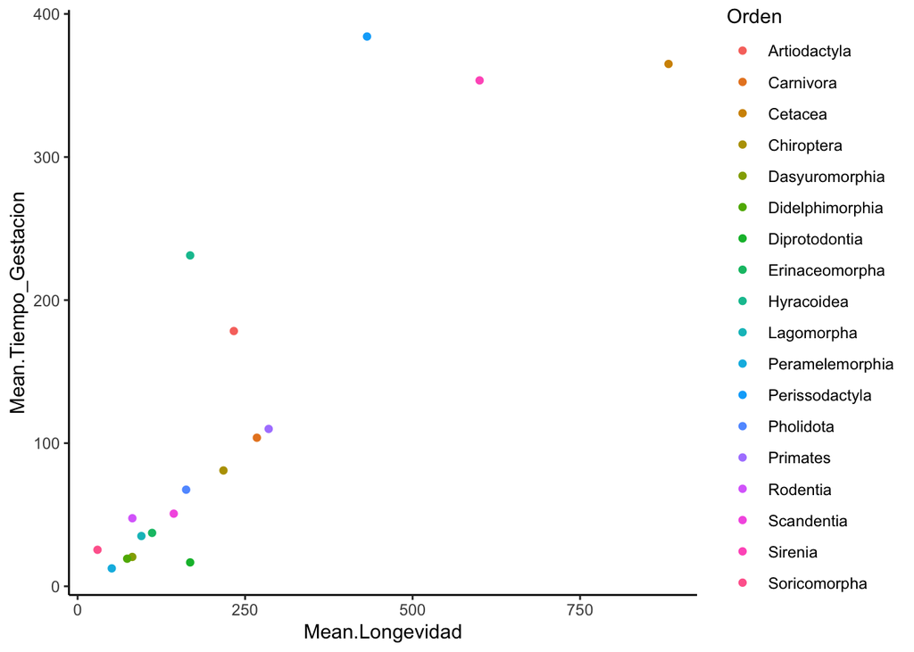

Figura 1, relación entre longevidad y Tiempo de gestación